# Replication of Elliots 2010 red study

*N* removed NAs: 3

*N* removed typo: 1

*N* removed <18: 17

*N* total clean: 129

| Group | *N* | *M*<sub>age</sub> | *M*<sub>rating</sub> |
| --- | --- | --- | --- |
| Control | 62 | 20.9 | 5.26 |
| Experim | 67 | 20.7 | 6.34 |

**Main analysis results**

*t*(127) = -7.23, *p* < .001

[interactive chart not shown]

[figure not shown]

[interactive chart not shown]

# Replication of Elliots 2010 red study

Analysing Data, Spring 2020

# Methods

## Participants

Table 1: Descriptive statistics of Age.

| *M*<sub>age</sub> | *SD*<sub>age</sub> | *MIN*<sub>age</sub> | *MAX*<sub>age</sub> |
| --- | --- | --- | --- |
| 20.8 | 1.83 | 18 | 26 |

Table 2: Descriptive statistics of Age by Condition.

| *Condition* | *N* | *%* | *M*<sub>age</sub> | *SD*<sub>age</sub> |
| --- | --- | --- | --- | --- |
| control | 62 | 48.1 | 20.9 | 1.68 |
| experimental | 67 | 51.9 | 20.7 | 1.96 |

## Design

The conceptual hypothesis is ‘does colour influence attractiveness?’ We will test this through copying Elliot’s ‘Experiment 1’ (Elliot et al., 2010, p. 403) wherein the independent variable will be a man associated with a red or white coloured background, operationalised by showing a photograph of a ‘moderately attractive’ set against a white or red frame. the dependent variable is a woman’s perceived attractiveness rating of a man. The replication is an independent measures laboratory study. The dependent variable is operationalised through a 3-question questionnaire, with items such as ‘how pleasant is this person to look at’ answered on a Likert scale, rated on a scale from 1-9; with 1 being: ‘not at all’, and 9 being ‘extremely so’. The operational hypothesis is ‘are a woman’s feelings of attraction for a moderately attractive man change when he is viewed in conjunction with different colour frames?’ To test this the answers for the 3 questions will be averaged to create a composite score and the means will be compared against the variation of the sample in an independent samples t-test.

# Results

We investigated whether women would rate a moderately attractive man as more attractive when viewed in conjunction with a red or white background, using an independent measures *t*-test. The analysis indicated, that as predicted, women who viewed the man in conjunction with a red background, gave higher mean ratings of attractiveness (*M* = 6.34) than participants in the control condition who viewed the man with a white background (*M* = 5.26). This difference in means was significant (*M*<sub>diff</sub> = 1.083), 95% CI -1.38, -0.79, *t* (127) = -7.23, *p* = <.001. This rejects the null hypothesis that colour has no effect on attraction for women to men, and provides support for the provided alternative, operationalised hypothesis.

Table 3: Descriptive statistics of Attractiveness Rating Response by Condition.

[output not shown]

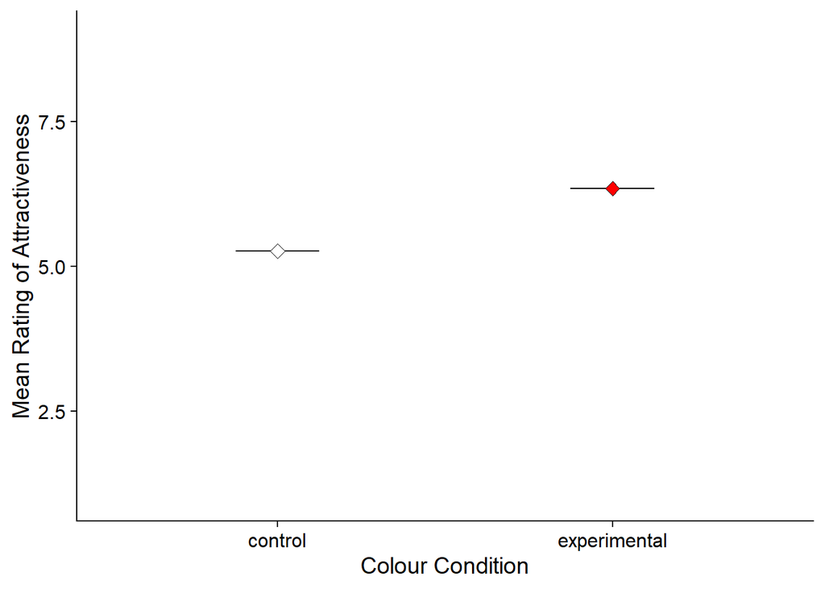

# Discussion

Our results found a 1.08 mean difference in average attraction between our two conditions, with those in the control condition presented with a white frame behind the moderately attractive man reporting an average of 5.26 attractiveness. Those in the experimental condition viewed the moderately attractive man in conjunction with a red background as an average of 6.34 in attractiveness. The P-value (= <0.001) indicates that it would be extremely unlikely to find the same effect in a similar sample if the null hypothesis were true, indicating support for our alternative hypothesis that a colour frame, and in particular red does have an impact on women’s rating of a man’s attractiveness. This supports the research question and the operational hypothesis that the background colour presented with a moderately attractive man would have an effect on the perceived attractiveness. The confidence intervals are small, indicating the results are likely to be found in other similar samples. Rendering the results strong and significant alongside the P-value. The statistic result (*t* = -7.23) answered the question by comparing the size of the difference between mean answers to all three attractive rating questions relative to the variation in our sample data. The negative result is because of the control condition mean being paired first against the experimental condition, wherein the control is lower, causing a negative value. These means compared answered which condition rated the man as more attractive. The high degrees of freedom (*df* = 127) occur because of our large sample size which strengthens the result in opposition to the null hypothesis.

Future research should interact with more cross-cultural and cross-educational level samples, to explore if this effect is universal. One strength of our research was its use of a sample from a different country (UK) to the original study (US), though contrapuntally, both are similar individualist cultures, and future research should focus on more diverse, collectivist cultures. A strength of this study is its laboratory design, ensuring a high control of variables, but perhaps presents limitations in lack of external validity, as the situation may not reflect real life. Future research could focus on more naturalistic settings, perhaps with a real life ‘moderately attractive’ man, against a more true-to-life, subtle red background. It would be interesting to compare results of this laboratory studies’ results versus a naturalistic setting, though rating variables could be disparate. Another possible idea for future research could also explore whether the red effect on attraction is bidirectional. Research (Peperkoorn et al., 2016) hasn’t found that red has an impact on males rating of women’s attractiveness, which poses the question, what is it about red and men specifically that has an attraction-enhancing effect? Some research has posed that it signifies potency and fecundity, exemplified by red mandrill’s capitalising off of their red colouring as a secondary sex characteristic and securing more mates, (Setchell & Dixson, 2001) suggesting red is a demonstration of testosterone, and alpha male qualities. Indeed, research has revealed red, in an attraction context, enhanced approach behaviour in primates (Meier et al., 2012) suggesting an evolutionary basis of the link. Unwrapping these early causes of attraction could help us better understand how much evolution plays a role in attraction today, implicating this research in the wider debate of nature versus nurture.

Another limitation of our replication is the use of means to create a composite score. Means, though a valid measure of central tendency, can be skewed by outliers, enhancing the found effect, perhaps rendering the effect larger than it actually is. A final limitation of the study is its independent measures design, beneficial to reduce/prevent the impacts of demand characteristics wherein participants guess the aims of the study, and the order effects of perhaps being bored or tired by attending both conditions, though introducing the prospect of individual differences as an intervening or extraneous variable. To avoid this, future research should endeavour to use a matched pairsdesign.

# References

Elliot, A. J., Niesta Kayser, D., Greitemeyer, T., Lichtenfeld, S., Gramzow, R. H., Maier, M. A., & Liu, H. (2010). Red, rank, and romance in women viewing men. *Journal of Experimental Psychology: General*, 139(3), 399–417. http://dx.doi.org/10.1037/a0019689

Francis, G. (2013). Publication bias in “Red, rank, and romance in women viewing men,” by Elliot et al. (2010). *Journal of Experimental Psychology: General*, 142(1), 292–296. http://dx.doi.org/10.1037/a0027923

Hesslinger, V. M., Goldbach, L., & Carbon, C.-C. (2015). Men in red: A reexamination of the red-attractiveness effect. *Psychonomic Bulletin & Review*, 22(4), 1142–1148. https://doi.org/10.3758/s13423-015-0866-8

Meier, B. P., D’Agostino, P. R., Elliot, A. J., Maier, M. A., & Wilkowski, B. M. (2012). Color in Context: Psychological Context Moderates the Influence of Red on Approach- and Avoidance-Motivated Behavior. *PLOS ONE*, 7(7), e40333. https://doi.org/10.1371/journal.pone.0040333

Peperkoorn, L. S., Roberts, S. C., & Pollet, T. V. (2016). Revisiting the Red Effect on Attractiveness and Sexual Receptivity: No Effect of the Color Red on Human Mate Preferences. *Evolutionary Psychology*, 14(4). https://doi.org/10.1177/1474704916673841

Setchell, J. M., & Dixson, A. F. (2001). Arrested development of secondary sexual adornments in subordinate adult male mandrills (Mandrillus sphinx). *American Journal of Physical Anthropology*, 115(3), 245–252. https://doi.org/10.1002/ajpa.1079